# Risk Factor Analysis

## Outcome Variable

**Outcome Variable:** stunted

## Predictor Variables

**Intervention Variable:** exclfeed3

**Adjustment Set:**

- arm
- sex
- W_mage
- meducyrs
- feducyrs
- hhwealth_quart
- hfoodsec
- W_mhtcm
- vagbrth
- W_gagebrth
- W_birthwt
- W_birthlen
- W_nrooms
- W_nchldlt5
- month
- brthmon
- W_parity
- impfloor
- impsan
- safeh20
- delta_W_mage
- delta_meducyrs
- delta_feducyrs
- delta_hhwealth_quart
- delta_hfoodsec
- delta_W_mhtcm
- delta_vagbrth
- delta_W_gagebrth
- delta_W_birthwt
- delta_W_birthlen
- delta_W_nrooms
- delta_W_nchldlt5
- delta_month
- delta_brthmon
- delta_W_parity
- delta_impfloor
- delta_impsan
- delta_safeh20

## Stratifying Variables

The analysis was stratified on these variable(s):

- agecat
- studyid
- country

## Data Summary

| agecat | studyid | country | exclfeed3 | stunted | n_cell | n |
| --- | --- | --- | --- | --- | --- | --- |
| Birth | ki0047075b-MAL-ED | BANGLADESH | 1 | 0 | 144 | 240 |
| Birth | ki0047075b-MAL-ED | BANGLADESH | 1 | 1 | 29 | 240 |
| Birth | ki0047075b-MAL-ED | BANGLADESH | 0 | 0 | 55 | 240 |
| Birth | ki0047075b-MAL-ED | BANGLADESH | 0 | 1 | 12 | 240 |
| Birth | ki0047075b-MAL-ED | BRAZIL | 1 | 0 | 63 | 185 |
| Birth | ki0047075b-MAL-ED | BRAZIL | 1 | 1 | 4 | 185 |
| Birth | ki0047075b-MAL-ED | BRAZIL | 0 | 0 | 103 | 185 |
| Birth | ki0047075b-MAL-ED | BRAZIL | 0 | 1 | 15 | 185 |
| Birth | ki0047075b-MAL-ED | INDIA | 1 | 0 | 103 | 196 |
| Birth | ki0047075b-MAL-ED | INDIA | 1 | 1 | 20 | 196 |
| Birth | ki0047075b-MAL-ED | INDIA | 0 | 0 | 62 | 196 |
| Birth | ki0047075b-MAL-ED | INDIA | 0 | 1 | 11 | 196 |
| Birth | ki0047075b-MAL-ED | NEPAL | 1 | 0 | 58 | 171 |
| Birth | ki0047075b-MAL-ED | NEPAL | 1 | 1 | 3 | 171 |
| Birth | ki0047075b-MAL-ED | NEPAL | 0 | 0 | 95 | 171 |
| Birth | ki0047075b-MAL-ED | NEPAL | 0 | 1 | 15 | 171 |
| Birth | ki0047075b-MAL-ED | PERU | 1 | 0 | 54 | 272 |
| Birth | ki0047075b-MAL-ED | PERU | 1 | 1 | 13 | 272 |
| Birth | ki0047075b-MAL-ED | PERU | 0 | 0 | 186 | 272 |
| Birth | ki0047075b-MAL-ED | PERU | 0 | 1 | 19 | 272 |
| Birth | ki0047075b-MAL-ED | SOUTH AFRICA | 1 | 0 | 29 | 233 |
| Birth | ki0047075b-MAL-ED | SOUTH AFRICA | 1 | 1 | 3 | 233 |
| Birth | ki0047075b-MAL-ED | SOUTH AFRICA | 0 | 0 | 180 | 233 |
| Birth | ki0047075b-MAL-ED | SOUTH AFRICA | 0 | 1 | 21 | 233 |
| Birth | ki0047075b-MAL-ED | TANZANIA, UNITED REPUBLIC OF | 1 | 0 | 35 | 119 |
| Birth | ki0047075b-MAL-ED | TANZANIA, UNITED REPUBLIC OF | 1 | 1 | 4 | 119 |
| Birth | ki0047075b-MAL-ED | TANZANIA, UNITED REPUBLIC OF | 0 | 0 | 66 | 119 |
| Birth | ki0047075b-MAL-ED | TANZANIA, UNITED REPUBLIC OF | 0 | 1 | 14 | 119 |
| Birth | ki1000108-CMC-V-BCS-2002 | INDIA | 1 | 0 | 4 | 4 |
| Birth | ki1000108-CMC-V-BCS-2002 | INDIA | 1 | 1 | 0 | 4 |

[output cut: 146 more lines]

The following strata were considered:

- agecat: 24 months, studyid: ki0047075b-MAL-ED, country: BANGLADESH
- agecat: 24 months, studyid: ki0047075b-MAL-ED, country: BRAZIL
- agecat: 24 months, studyid: ki0047075b-MAL-ED, country: INDIA
- agecat: 24 months, studyid: ki0047075b-MAL-ED, country: NEPAL
- agecat: 24 months, studyid: ki0047075b-MAL-ED, country: PERU
- agecat: 24 months, studyid: ki0047075b-MAL-ED, country: SOUTH AFRICA
- agecat: 24 months, studyid: ki0047075b-MAL-ED, country: TANZANIA, UNITED REPUBLIC OF
- agecat: 24 months, studyid: ki1000108-CMC-V-BCS-2002, country: INDIA
- agecat: 24 months, studyid: ki1000108-IRC, country: INDIA
- agecat: 24 months, studyid: ki1017093b-PROVIDE, country: BANGLADESH
- agecat: 24 months, studyid: ki1101329-Keneba, country: GAMBIA
- agecat: 24 months, studyid: ki1113344-GMS-Nepal, country: NEPAL
- agecat: 24 months, studyid: kiGH5241-JiVitA-3, country: BANGLADESH
- agecat: 24 months, studyid: kiGH5241-JiVitA-4, country: BANGLADESH
- agecat: 6 months, studyid: ki0047075b-MAL-ED, country: BANGLADESH
- agecat: 6 months, studyid: ki0047075b-MAL-ED, country: BRAZIL
- agecat: 6 months, studyid: ki0047075b-MAL-ED, country: INDIA
- agecat: 6 months, studyid: ki0047075b-MAL-ED, country: NEPAL
- agecat: 6 months, studyid: ki0047075b-MAL-ED, country: PERU
- agecat: 6 months, studyid: ki0047075b-MAL-ED, country: SOUTH AFRICA
- agecat: 6 months, studyid: ki0047075b-MAL-ED, country: TANZANIA, UNITED REPUBLIC OF
- agecat: 6 months, studyid: ki1000108-CMC-V-BCS-2002, country: INDIA
- agecat: 6 months, studyid: ki1000108-IRC, country: INDIA
- agecat: 6 months, studyid: ki1000109-EE, country: PAKISTAN
- agecat: 6 months, studyid: ki1000304b-SAS-CompFeed, country: INDIA
- agecat: 6 months, studyid: ki1017093b-PROVIDE, country: BANGLADESH
- agecat: 6 months, studyid: ki1101329-Keneba, country: GAMBIA
- agecat: 6 months, studyid: ki1113344-GMS-Nepal, country: NEPAL
- agecat: 6 months, studyid: kiGH5241-JiVitA-3, country: BANGLADESH
- agecat: 6 months, studyid: kiGH5241-JiVitA-4, country: BANGLADESH
- agecat: Birth, studyid: ki0047075b-MAL-ED, country: BANGLADESH
- agecat: Birth, studyid: ki0047075b-MAL-ED, country: BRAZIL
- agecat: Birth, studyid: ki0047075b-MAL-ED, country: INDIA
- agecat: Birth, studyid: ki0047075b-MAL-ED, country: NEPAL
- agecat: Birth, studyid: ki0047075b-MAL-ED, country: PERU
- agecat: Birth, studyid: ki0047075b-MAL-ED, country: SOUTH AFRICA
- agecat: Birth, studyid: ki0047075b-MAL-ED, country: TANZANIA, UNITED REPUBLIC OF
- agecat: Birth, studyid: ki1000108-CMC-V-BCS-2002, country: INDIA
- agecat: Birth, studyid: ki1000108-IRC, country: INDIA
- agecat: Birth, studyid: ki1000109-EE, country: PAKISTAN
- agecat: Birth, studyid: ki1000304b-SAS-CompFeed, country: INDIA
- agecat: Birth, studyid: ki1101329-Keneba, country: GAMBIA
- agecat: Birth, studyid: kiGH5241-JiVitA-3, country: BANGLADESH
- agecat: Birth, studyid: kiGH5241-JiVitA-4, country: BANGLADESH

### Dropped Strata

Some strata were dropped due to rare outcomes:

- agecat: Birth, studyid: ki0047075b-MAL-ED, country: BRAZIL
- agecat: Birth, studyid: ki0047075b-MAL-ED, country: NEPAL
- agecat: Birth, studyid: ki0047075b-MAL-ED, country: SOUTH AFRICA
- agecat: Birth, studyid: ki0047075b-MAL-ED, country: TANZANIA, UNITED REPUBLIC OF
- agecat: Birth, studyid: ki1000108-CMC-V-BCS-2002, country: INDIA
- agecat: Birth, studyid: ki1000108-IRC, country: INDIA
- agecat: Birth, studyid: ki1000109-EE, country: PAKISTAN
- agecat: Birth, studyid: ki1000304b-SAS-CompFeed, country: INDIA
- agecat: Birth, studyid: kiGH5241-JiVitA-4, country: BANGLADESH
- agecat: 6 months, studyid: ki0047075b-MAL-ED, country: BRAZIL
- agecat: 6 months, studyid: ki0047075b-MAL-ED, country: SOUTH AFRICA
- agecat: 6 months, studyid: ki1000108-CMC-V-BCS-2002, country: INDIA
- agecat: 6 months, studyid: ki1000108-IRC, country: INDIA
- agecat: 24 months, studyid: ki0047075b-MAL-ED, country: BRAZIL
- agecat: 24 months, studyid: ki1000108-CMC-V-BCS-2002, country: INDIA
- agecat: 24 months, studyid: ki1000108-IRC, country: INDIA

## Methods Detail

We’re interested in the causal parameters $E[Y_a]$ for all values of $a \in \mathcal{A}$. These parameters represent the mean outcome if, possibly contrary to fact, we intervened to set all units to have $A=a$. Under the randomization and positivity assumptions, these are identified by the statistical parameters $\psi_a=E_W[E_{Y|A,W}(Y|A=a,W)]$. In addition, we’re interested in the mean of $Y$, $E[Y]$ under no intervention (the observed mean). We will estimate these parameters by using SuperLearner to fit the relevant likelihood factors – $E_{Y|A,W}(Y|A=a,W)$ and $p(A=a|W)$, and then updating our likelihood fit using a joint TMLE.

For unadjusted analyses ($W=\{\}$), initial likelihoods were estimated using Lrnr_glm to estimate the simple $E(Y|A)$ and Lrnr_mean to estimate $p(A)$. For adjusted analyses, a small library containing Lrnr_glmnet, Lrnr_xgboost, and Lrnr_mean was used.

Having estimated these parameters, we will then use the delta method to estimate relative risks and attributable risks relative to a prespecified baseline level of $A$.

# Results Detail

## Results Plots

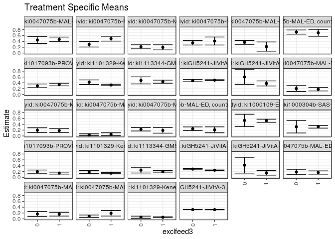

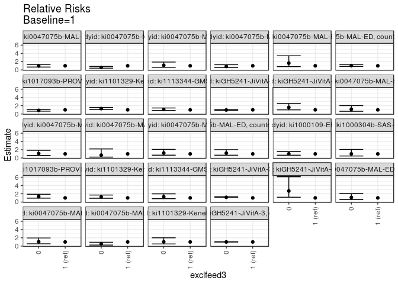

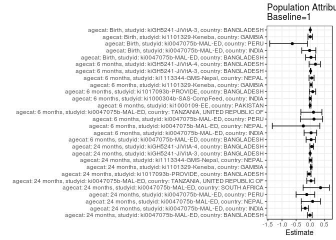

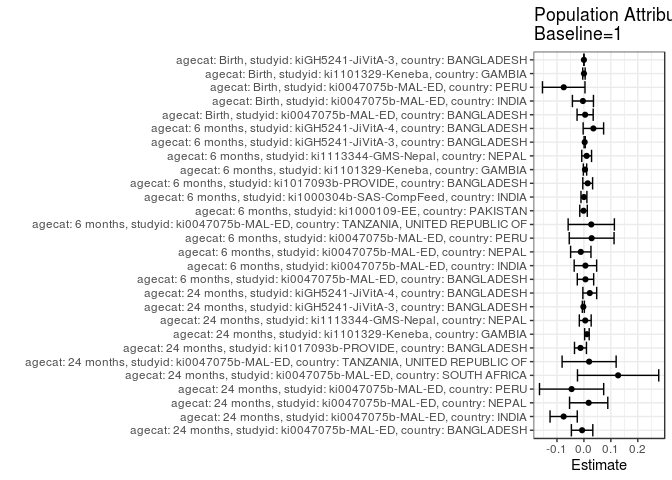

## Results Table

### Parameter: TSM

| agecat | studyid | country | intervention_level | baseline_level | estimate | ci_lower | ci_upper |
| --- | --- | --- | --- | --- | --- | --- | --- |
| Birth | ki0047075b-MAL-ED | BANGLADESH | 1 | NA | 0.1662911 | 0.1107298 | 0.2218523 |
| Birth | ki0047075b-MAL-ED | BANGLADESH | 0 | NA | 0.1850244 | 0.0922456 | 0.2778032 |
| Birth | ki0047075b-MAL-ED | INDIA | 1 | NA | 0.1617845 | 0.0964030 | 0.2271660 |
| Birth | ki0047075b-MAL-ED | INDIA | 0 | NA | 0.1681207 | 0.0864405 | 0.2498009 |
| Birth | ki0047075b-MAL-ED | PERU | 1 | NA | 0.1925401 | 0.0965241 | 0.2885561 |
| Birth | ki0047075b-MAL-ED | PERU | 0 | NA | 0.0920410 | 0.0521693 | 0.1319127 |
| Birth | ki1101329-Keneba | GAMBIA | 1 | NA | 0.0560201 | 0.0429825 | 0.0690576 |
| Birth | ki1101329-Keneba | GAMBIA | 0 | NA | 0.0569620 | 0.0208096 | 0.0931144 |
| Birth | kiGH5241-JiVitA-3 | BANGLADESH | 1 | NA | 0.3155260 | 0.3079566 | 0.3230954 |
| Birth | kiGH5241-JiVitA-3 | BANGLADESH | 0 | NA | 0.3161058 | 0.3085172 | 0.3236944 |
| 6 months | ki0047075b-MAL-ED | BANGLADESH | 1 | NA | 0.1798382 | 0.1225323 | 0.2371441 |
| 6 months | ki0047075b-MAL-ED | BANGLADESH | 0 | NA | 0.2051361 | 0.1066399 | 0.3036323 |
| 6 months | ki0047075b-MAL-ED | INDIA | 1 | NA | 0.1832753 | 0.1185049 | 0.2480457 |
| 6 months | ki0047075b-MAL-ED | INDIA | 0 | NA | 0.1965199 | 0.1134872 | 0.2795526 |
| 6 months | ki0047075b-MAL-ED | NEPAL | 1 | NA | 0.0588235 | 0.0086951 | 0.1089519 |
| 6 months | ki0047075b-MAL-ED | NEPAL | 0 | NA | 0.0405405 | 0.0086979 | 0.0723832 |
| 6 months | ki0047075b-MAL-ED | PERU | 1 | NA | 0.1898193 | 0.0953949 | 0.2842437 |
| 6 months | ki0047075b-MAL-ED | PERU | 0 | NA | 0.2273673 | 0.1694067 | 0.2853279 |
| 6 months | ki0047075b-MAL-ED | TANZANIA, UNITED REPUBLIC OF | 1 | NA | 0.2102303 | 0.1089334 | 0.3115272 |
| 6 months | ki0047075b-MAL-ED | TANZANIA, UNITED REPUBLIC OF | 0 | NA | 0.2457248 | 0.1819133 | 0.3095363 |
| 6 months | ki1000109-EE | PAKISTAN | 1 | NA | 0.5216303 | 0.4688300 | 0.5744305 |
| 6 months | ki1000109-EE | PAKISTAN | 0 | NA | 0.5320681 | 0.3195043 | 0.7446320 |
| 6 months | ki1000304b-SAS-CompFeed | INDIA | 1 | NA | 0.3139842 | 0.2679102 | 0.3600581 |
| 6 months | ki1000304b-SAS-CompFeed | INDIA | 0 | NA | 0.3157895 | 0.1014523 | 0.5301266 |
| 6 months | ki1017093b-PROVIDE | BANGLADESH | 1 | NA | 0.1471732 | 0.1136935 | 0.1806530 |
| 6 months | ki1017093b-PROVIDE | BANGLADESH | 0 | NA | 0.1962124 | 0.1406149 | 0.2518098 |
| 6 months | ki1101329-Keneba | GAMBIA | 1 | NA | 0.1446314 | 0.1270732 | 0.1621895 |
| 6 months | ki1101329-Keneba | GAMBIA | 0 | NA | 0.1798656 | 0.1284475 | 0.2312838 |
| 6 months | ki1113344-GMS-Nepal | NEPAL | 1 | NA | 0.1950609 | 0.1550527 | 0.2350690 |
| 6 months | ki1113344-GMS-Nepal | NEPAL | 0 | NA | 0.2474514 | 0.1496169 | 0.3452860 |
| 6 months | kiGH5241-JiVitA-3 | BANGLADESH | 1 | NA | 0.2460653 | 0.2375848 | 0.2545458 |
| 6 months | kiGH5241-JiVitA-3 | BANGLADESH | 0 | NA | 0.2841376 | 0.2613949 | 0.3068802 |
| 6 months | kiGH5241-JiVitA-4 | BANGLADESH | 1 | NA | 0.1558442 | 0.0767551 | 0.2349333 |
| 6 months | kiGH5241-JiVitA-4 | BANGLADESH | 0 | NA | 0.4166667 | 0.1460475 | 0.6872858 |
| 24 months | ki0047075b-MAL-ED | BANGLADESH | 1 | NA | 0.4682340 | 0.3889176 | 0.5475504 |
| 24 months | ki0047075b-MAL-ED | BANGLADESH | 0 | NA | 0.4469164 | 0.3236853 | 0.5701475 |
| 24 months | ki0047075b-MAL-ED | INDIA | 1 | NA | 0.4929344 | 0.4095086 | 0.5763601 |
| 24 months | ki0047075b-MAL-ED | INDIA | 0 | NA | 0.2988459 | 0.2075728 | 0.3901189 |
| 24 months | ki0047075b-MAL-ED | NEPAL | 1 | NA | 0.1956734 | 0.1085834 | 0.2827633 |
| 24 months | ki0047075b-MAL-ED | NEPAL | 0 | NA | 0.2146437 | 0.1462181 | 0.2830693 |
| 24 months | ki0047075b-MAL-ED | PERU | 1 | NA | 0.4125535 | 0.2756443 | 0.5494627 |
| 24 months | ki0047075b-MAL-ED | PERU | 0 | NA | 0.3513841 | 0.2753253 | 0.4274428 |
| 24 months | ki0047075b-MAL-ED | SOUTH AFRICA | 1 | NA | 0.2222222 | 0.0650681 | 0.3793763 |
| 24 months | ki0047075b-MAL-ED | SOUTH AFRICA | 0 | NA | 0.3658537 | 0.2997755 | 0.4319318 |
| 24 months | ki0047075b-MAL-ED | TANZANIA, UNITED REPUBLIC OF | 1 | NA | 0.6949461 | 0.5762620 | 0.8136302 |
| 24 months | ki0047075b-MAL-ED | TANZANIA, UNITED REPUBLIC OF | 0 | NA | 0.7197504 | 0.6485901 | 0.7909108 |
| 24 months | ki1017093b-PROVIDE | BANGLADESH | 1 | NA | 0.3420449 | 0.2967382 | 0.3873515 |
| 24 months | ki1017093b-PROVIDE | BANGLADESH | 0 | NA | 0.2966452 | 0.2322753 | 0.3610151 |
| 24 months | ki1101329-Keneba | GAMBIA | 1 | NA | 0.3269094 | 0.3012532 | 0.3525656 |
| 24 months | ki1101329-Keneba | GAMBIA | 0 | NA | 0.4223292 | 0.3442550 | 0.5004034 |
| 24 months | ki1113344-GMS-Nepal | NEPAL | 1 | NA | 0.4405922 | 0.3874225 | 0.4937619 |
| 24 months | ki1113344-GMS-Nepal | NEPAL | 0 | NA | 0.4835938 | 0.3628275 | 0.6043601 |
| 24 months | kiGH5241-JiVitA-3 | BANGLADESH | 1 | NA | 0.4925025 | 0.4784751 | 0.5065299 |
| 24 months | kiGH5241-JiVitA-3 | BANGLADESH | 0 | NA | 0.4738033 | 0.4361995 | 0.5114071 |
| 24 months | kiGH5241-JiVitA-4 | BANGLADESH | 1 | NA | 0.3795620 | 0.2934360 | 0.4656880 |
| 24 months | kiGH5241-JiVitA-4 | BANGLADESH | 0 | NA | 0.6000000 | 0.3502268 | 0.8497732 |

### Parameter: E(Y)

| agecat | studyid | country | intervention_level | baseline_level | estimate | ci_lower | ci_upper |
| --- | --- | --- | --- | --- | --- | --- | --- |
| Birth | ki0047075b-MAL-ED | BANGLADESH | NA | NA | 0.1708333 | 0.1231182 | 0.2185485 |
| Birth | ki0047075b-MAL-ED | INDIA | NA | NA | 0.1581633 | 0.1069482 | 0.2093783 |
| Birth | ki0047075b-MAL-ED | PERU | NA | NA | 0.1176471 | 0.0792874 | 0.1560068 |
| Birth | ki1101329-Keneba | GAMBIA | NA | NA | 0.0561300 | 0.0438654 | 0.0683946 |
| Birth | kiGH5241-JiVitA-3 | BANGLADESH | NA | NA | 0.3156066 | 0.3080361 | 0.3231771 |
| 6 months | ki0047075b-MAL-ED | BANGLADESH | NA | NA | 0.1856540 | 0.1360463 | 0.2352617 |
| 6 months | ki0047075b-MAL-ED | INDIA | NA | NA | 0.1888412 | 0.1384789 | 0.2392035 |
| 6 months | ki0047075b-MAL-ED | NEPAL | NA | NA | 0.0472103 | 0.0199192 | 0.0745014 |
| 6 months | ki0047075b-MAL-ED | PERU | NA | NA | 0.2185185 | 0.1691358 | 0.2679013 |
| 6 months | ki0047075b-MAL-ED | TANZANIA, UNITED REPUBLIC OF | NA | NA | 0.2375000 | 0.1835488 | 0.2914512 |
| 6 months | ki1000109-EE | PAKISTAN | NA | NA | 0.5202156 | 0.4693105 | 0.5711208 |
| 6 months | ki1000304b-SAS-CompFeed | INDIA | NA | NA | 0.3140704 | 0.2712850 | 0.3568557 |
| 6 months | ki1017093b-PROVIDE | BANGLADESH | NA | NA | 0.1612350 | 0.1313580 | 0.1911120 |
| 6 months | ki1101329-Keneba | GAMBIA | NA | NA | 0.1486797 | 0.1319680 | 0.1653914 |
| 6 months | ki1113344-GMS-Nepal | NEPAL | NA | NA | 0.2052402 | 0.1682114 | 0.2422689 |
| 6 months | kiGH5241-JiVitA-3 | BANGLADESH | NA | NA | 0.2489405 | 0.2407278 | 0.2571531 |
| 6 months | kiGH5241-JiVitA-4 | BANGLADESH | NA | NA | 0.1910112 | 0.1139351 | 0.2680874 |
| 24 months | ki0047075b-MAL-ED | BANGLADESH | NA | NA | 0.4615385 | 0.3936268 | 0.5294501 |
| 24 months | ki0047075b-MAL-ED | INDIA | NA | NA | 0.4177778 | 0.3531914 | 0.4823642 |
| 24 months | ki0047075b-MAL-ED | NEPAL | NA | NA | 0.2133333 | 0.1596859 | 0.2669808 |
| 24 months | ki0047075b-MAL-ED | PERU | NA | NA | 0.3668342 | 0.2997053 | 0.4339630 |
| 24 months | ki0047075b-MAL-ED | SOUTH AFRICA | NA | NA | 0.3491379 | 0.2876648 | 0.4106110 |
| 24 months | ki0047075b-MAL-ED | TANZANIA, UNITED REPUBLIC OF | NA | NA | 0.7142857 | 0.6530398 | 0.7755316 |
| 24 months | ki1017093b-PROVIDE | BANGLADESH | NA | NA | 0.3292894 | 0.2909105 | 0.3676684 |
| 24 months | ki1101329-Keneba | GAMBIA | NA | NA | 0.3380282 | 0.3134158 | 0.3626405 |
| 24 months | ki1113344-GMS-Nepal | NEPAL | NA | NA | 0.4455446 | 0.3970186 | 0.4940706 |
| 24 months | kiGH5241-JiVitA-3 | BANGLADESH | NA | NA | 0.4904688 | 0.4770397 | 0.5038978 |
| 24 months | kiGH5241-JiVitA-4 | BANGLADESH | NA | NA | 0.4013158 | 0.3195309 | 0.4831007 |

### Parameter: RR

| agecat | studyid | country | intervention_level | baseline_level | estimate | ci_lower | ci_upper |
| --- | --- | --- | --- | --- | --- | --- | --- |
| Birth | ki0047075b-MAL-ED | BANGLADESH | 1 | 1 | 1.0000000 | 1.0000000 | 1.0000000 |
| Birth | ki0047075b-MAL-ED | BANGLADESH | 0 | 1 | 1.1126540 | 0.6091558 | 2.0323190 |
| Birth | ki0047075b-MAL-ED | INDIA | 1 | 1 | 1.0000000 | 1.0000000 | 1.0000000 |
| Birth | ki0047075b-MAL-ED | INDIA | 0 | 1 | 1.0391645 | 0.5528168 | 1.9533828 |
| Birth | ki0047075b-MAL-ED | PERU | 1 | 1 | 1.0000000 | 1.0000000 | 1.0000000 |
| Birth | ki0047075b-MAL-ED | PERU | 0 | 1 | 0.4780355 | 0.2466780 | 0.9263816 |
| Birth | ki1101329-Keneba | GAMBIA | 1 | 1 | 1.0000000 | 1.0000000 | 1.0000000 |
| Birth | ki1101329-Keneba | GAMBIA | 0 | 1 | 1.0168147 | 0.5172001 | 1.9990563 |
| Birth | kiGH5241-JiVitA-3 | BANGLADESH | 1 | 1 | 1.0000000 | 1.0000000 | 1.0000000 |
| Birth | kiGH5241-JiVitA-3 | BANGLADESH | 0 | 1 | 1.0018376 | 1.0005758 | 1.0031011 |
| 6 months | ki0047075b-MAL-ED | BANGLADESH | 1 | 1 | 1.0000000 | 1.0000000 | 1.0000000 |
| 6 months | ki0047075b-MAL-ED | BANGLADESH | 0 | 1 | 1.1406702 | 0.6445283 | 2.0187300 |
| 6 months | ki0047075b-MAL-ED | INDIA | 1 | 1 | 1.0000000 | 1.0000000 | 1.0000000 |
| 6 months | ki0047075b-MAL-ED | INDIA | 0 | 1 | 1.0722661 | 0.6166313 | 1.8645737 |
| 6 months | ki0047075b-MAL-ED | NEPAL | 1 | 1 | 1.0000000 | 1.0000000 | 1.0000000 |
| 6 months | ki0047075b-MAL-ED | NEPAL | 0 | 1 | 0.6891892 | 0.2162797 | 2.1961461 |
| 6 months | ki0047075b-MAL-ED | PERU | 1 | 1 | 1.0000000 | 1.0000000 | 1.0000000 |
| 6 months | ki0047075b-MAL-ED | PERU | 0 | 1 | 1.1978094 | 0.6857877 | 2.0921159 |
| 6 months | ki0047075b-MAL-ED | TANZANIA, UNITED REPUBLIC OF | 1 | 1 | 1.0000000 | 1.0000000 | 1.0000000 |
| 6 months | ki0047075b-MAL-ED | TANZANIA, UNITED REPUBLIC OF | 0 | 1 | 1.1688365 | 0.6778294 | 2.0155203 |
| 6 months | ki1000109-EE | PAKISTAN | 1 | 1 | 1.0000000 | 1.0000000 | 1.0000000 |
| 6 months | ki1000109-EE | PAKISTAN | 0 | 1 | 1.0200101 | 0.6751752 | 1.5409638 |
| 6 months | ki1000304b-SAS-CompFeed | INDIA | 1 | 1 | 1.0000000 | 1.0000000 | 1.0000000 |
| 6 months | ki1000304b-SAS-CompFeed | INDIA | 0 | 1 | 1.0057497 | 0.4866253 | 2.0786680 |
| 6 months | ki1017093b-PROVIDE | BANGLADESH | 1 | 1 | 1.0000000 | 1.0000000 | 1.0000000 |
| 6 months | ki1017093b-PROVIDE | BANGLADESH | 0 | 1 | 1.3332071 | 0.9427480 | 1.8853832 |
| 6 months | ki1101329-Keneba | GAMBIA | 1 | 1 | 1.0000000 | 1.0000000 | 1.0000000 |
| 6 months | ki1101329-Keneba | GAMBIA | 0 | 1 | 1.2436142 | 0.9133969 | 1.6932138 |
| 6 months | ki1113344-GMS-Nepal | NEPAL | 1 | 1 | 1.0000000 | 1.0000000 | 1.0000000 |
| 6 months | ki1113344-GMS-Nepal | NEPAL | 0 | 1 | 1.2685858 | 0.8119898 | 1.9819337 |
| 6 months | kiGH5241-JiVitA-3 | BANGLADESH | 1 | 1 | 1.0000000 | 1.0000000 | 1.0000000 |
| 6 months | kiGH5241-JiVitA-3 | BANGLADESH | 0 | 1 | 1.1547241 | 1.0632007 | 1.2541261 |
| 6 months | kiGH5241-JiVitA-4 | BANGLADESH | 1 | 1 | 1.0000000 | 1.0000000 | 1.0000000 |
| 6 months | kiGH5241-JiVitA-4 | BANGLADESH | 0 | 1 | 2.6736111 | 1.1673323 | 6.1235320 |
| 24 months | ki0047075b-MAL-ED | BANGLADESH | 1 | 1 | 1.0000000 | 1.0000000 | 1.0000000 |
| 24 months | ki0047075b-MAL-ED | BANGLADESH | 0 | 1 | 0.9544723 | 0.6946589 | 1.3114601 |
| 24 months | ki0047075b-MAL-ED | INDIA | 1 | 1 | 1.0000000 | 1.0000000 | 1.0000000 |
| 24 months | ki0047075b-MAL-ED | INDIA | 0 | 1 | 0.6062590 | 0.4310035 | 0.8527772 |
| 24 months | ki0047075b-MAL-ED | NEPAL | 1 | 1 | 1.0000000 | 1.0000000 | 1.0000000 |
| 24 months | ki0047075b-MAL-ED | NEPAL | 0 | 1 | 1.0969491 | 0.6330632 | 1.9007538 |
| 24 months | ki0047075b-MAL-ED | PERU | 1 | 1 | 1.0000000 | 1.0000000 | 1.0000000 |
| 24 months | ki0047075b-MAL-ED | PERU | 0 | 1 | 0.8517297 | 0.5772448 | 1.2567345 |
| 24 months | ki0047075b-MAL-ED | SOUTH AFRICA | 1 | 1 | 1.0000000 | 1.0000000 | 1.0000000 |
| 24 months | ki0047075b-MAL-ED | SOUTH AFRICA | 0 | 1 | 1.6463415 | 0.7934716 | 3.4159258 |
| 24 months | ki0047075b-MAL-ED | TANZANIA, UNITED REPUBLIC OF | 1 | 1 | 1.0000000 | 1.0000000 | 1.0000000 |
| 24 months | ki0047075b-MAL-ED | TANZANIA, UNITED REPUBLIC OF | 0 | 1 | 1.0356925 | 0.8518955 | 1.2591440 |
| 24 months | ki1017093b-PROVIDE | BANGLADESH | 1 | 1 | 1.0000000 | 1.0000000 | 1.0000000 |
| 24 months | ki1017093b-PROVIDE | BANGLADESH | 0 | 1 | 0.8672699 | 0.6782913 | 1.1088998 |
| 24 months | ki1101329-Keneba | GAMBIA | 1 | 1 | 1.0000000 | 1.0000000 | 1.0000000 |
| 24 months | ki1101329-Keneba | GAMBIA | 0 | 1 | 1.2918847 | 1.0589932 | 1.5759932 |
| 24 months | ki1113344-GMS-Nepal | NEPAL | 1 | 1 | 1.0000000 | 1.0000000 | 1.0000000 |
| 24 months | ki1113344-GMS-Nepal | NEPAL | 0 | 1 | 1.0975996 | 0.8317657 | 1.4483945 |
| 24 months | kiGH5241-JiVitA-3 | BANGLADESH | 1 | 1 | 1.0000000 | 1.0000000 | 1.0000000 |
| 24 months | kiGH5241-JiVitA-3 | BANGLADESH | 0 | 1 | 0.9620322 | 0.8860447 | 1.0445365 |
| 24 months | kiGH5241-JiVitA-4 | BANGLADESH | 1 | 1 | 1.0000000 | 1.0000000 | 1.0000000 |
| 24 months | kiGH5241-JiVitA-4 | BANGLADESH | 0 | 1 | 1.5807692 | 0.9874364 | 2.5306252 |

### Parameter: PAR

| agecat | studyid | country | intervention_level | baseline_level | estimate | ci_lower | ci_upper |
| --- | --- | --- | --- | --- | --- | --- | --- |
| Birth | ki0047075b-MAL-ED | BANGLADESH | 1 | NA | 0.0045423 | -0.0253758 | 0.0344603 |
| Birth | ki0047075b-MAL-ED | INDIA | 1 | NA | -0.0036212 | -0.0426684 | 0.0354260 |
| Birth | ki0047075b-MAL-ED | PERU | 1 | NA | -0.0748930 | -0.1538010 | 0.0040149 |
| Birth | ki1101329-Keneba | GAMBIA | 1 | NA | 0.0001099 | -0.0043747 | 0.0045946 |
| Birth | kiGH5241-JiVitA-3 | BANGLADESH | 1 | NA | 0.0000806 | 0.0000350 | 0.0001263 |
| 6 months | ki0047075b-MAL-ED | BANGLADESH | 1 | NA | 0.0058158 | -0.0245694 | 0.0362010 |
| 6 months | ki0047075b-MAL-ED | INDIA | 1 | NA | 0.0055659 | -0.0361223 | 0.0472541 |
| 6 months | ki0047075b-MAL-ED | NEPAL | 1 | NA | -0.0116132 | -0.0493524 | 0.0261259 |
| 6 months | ki0047075b-MAL-ED | PERU | 1 | NA | 0.0286992 | -0.0544873 | 0.1118858 |
| 6 months | ki0047075b-MAL-ED | TANZANIA, UNITED REPUBLIC OF | 1 | NA | 0.0272697 | -0.0585316 | 0.1130710 |
| 6 months | ki1000109-EE | PAKISTAN | 1 | NA | -0.0014146 | -0.0153458 | 0.0125165 |
| 6 months | ki1000304b-SAS-CompFeed | INDIA | 1 | NA | 0.0000862 | -0.0108674 | 0.0110398 |
| 6 months | ki1017093b-PROVIDE | BANGLADESH | 1 | NA | 0.0140618 | -0.0041260 | 0.0322495 |
| 6 months | ki1101329-Keneba | GAMBIA | 1 | NA | 0.0040483 | -0.0021318 | 0.0102284 |
| 6 months | ki1113344-GMS-Nepal | NEPAL | 1 | NA | 0.0101793 | -0.0080259 | 0.0283845 |
| 6 months | kiGH5241-JiVitA-3 | BANGLADESH | 1 | NA | 0.0028752 | 0.0007311 | 0.0050192 |
| 6 months | kiGH5241-JiVitA-4 | BANGLADESH | 1 | NA | 0.0351671 | -0.0027750 | 0.0731092 |
| 24 months | ki0047075b-MAL-ED | BANGLADESH | 1 | NA | -0.0066955 | -0.0464110 | 0.0330199 |
| 24 months | ki0047075b-MAL-ED | INDIA | 1 | NA | -0.0751566 | -0.1256440 | -0.0246692 |
| 24 months | ki0047075b-MAL-ED | NEPAL | 1 | NA | 0.0176600 | -0.0533212 | 0.0886411 |
| 24 months | ki0047075b-MAL-ED | PERU | 1 | NA | -0.0457193 | -0.1648149 | 0.0733762 |
| 24 months | ki0047075b-MAL-ED | SOUTH AFRICA | 1 | NA | 0.1269157 | -0.0238418 | 0.2776732 |
| 24 months | ki0047075b-MAL-ED | TANZANIA, UNITED REPUBLIC OF | 1 | NA | 0.0193397 | -0.0809388 | 0.1196181 |
| 24 months | ki1017093b-PROVIDE | BANGLADESH | 1 | NA | -0.0127554 | -0.0349344 | 0.0094236 |
| 24 months | ki1101329-Keneba | GAMBIA | 1 | NA | 0.0111188 | 0.0026927 | 0.0195449 |
| 24 months | ki1113344-GMS-Nepal | NEPAL | 1 | NA | 0.0049524 | -0.0170298 | 0.0269345 |
| 24 months | kiGH5241-JiVitA-3 | BANGLADESH | 1 | NA | -0.0020337 | -0.0058289 | 0.0017614 |
| 24 months | kiGH5241-JiVitA-4 | BANGLADESH | 1 | NA | 0.0217537 | -0.0039060 | 0.0474135 |

### Parameter: PAF

| agecat | studyid | country | intervention_level | baseline_level | estimate | ci_lower | ci_upper |
| --- | --- | --- | --- | --- | --- | --- | --- |
| Birth | ki0047075b-MAL-ED | BANGLADESH | 1 | NA | 0.0265889 | -0.1652085 | 0.1868158 |
| Birth | ki0047075b-MAL-ED | INDIA | 1 | NA | -0.0228954 | -0.3019575 | 0.1963523 |
| Birth | ki0047075b-MAL-ED | PERU | 1 | NA | -0.6365907 | -1.4351521 | -0.0999022 |
| Birth | ki1101329-Keneba | GAMBIA | 1 | NA | 0.0019583 | -0.0812232 | 0.0787404 |
| Birth | kiGH5241-JiVitA-3 | BANGLADESH | 1 | NA | 0.0002555 | 0.0001109 | 0.0004000 |
| 6 months | ki0047075b-MAL-ED | BANGLADESH | 1 | NA | 0.0313260 | -0.1469030 | 0.1818582 |
| 6 months | ki0047075b-MAL-ED | INDIA | 1 | NA | 0.0294740 | -0.2183979 | 0.2269186 |
| 6 months | ki0047075b-MAL-ED | NEPAL | 1 | NA | -0.2459893 | -1.3455873 | 0.3381234 |
| 6 months | ki0047075b-MAL-ED | PERU | 1 | NA | 0.1313355 | -0.3457252 | 0.4392777 |
| 6 months | ki0047075b-MAL-ED | TANZANIA, UNITED REPUBLIC OF | 1 | NA | 0.1148199 | -0.3326796 | 0.4120539 |
| 6 months | ki1000109-EE | PAKISTAN | 1 | NA | -0.0027193 | -0.0298606 | 0.0237067 |
| 6 months | ki1000304b-SAS-CompFeed | INDIA | 1 | NA | 0.0002744 | -0.0352245 | 0.0345560 |
| 6 months | ki1017093b-PROVIDE | BANGLADESH | 1 | NA | 0.0872130 | -0.0324401 | 0.1929991 |
| 6 months | ki1101329-Keneba | GAMBIA | 1 | NA | 0.0272283 | -0.0152148 | 0.0678969 |
| 6 months | ki1113344-GMS-Nepal | NEPAL | 1 | NA | 0.0495971 | -0.0431287 | 0.1340804 |
| 6 months | kiGH5241-JiVitA-3 | BANGLADESH | 1 | NA | 0.0115496 | 0.0028923 | 0.0201318 |
| 6 months | kiGH5241-JiVitA-4 | BANGLADESH | 1 | NA | 0.1841100 | -0.0402855 | 0.3601021 |
| 24 months | ki0047075b-MAL-ED | BANGLADESH | 1 | NA | -0.0145070 | -0.1042969 | 0.0679821 |
| 24 months | ki0047075b-MAL-ED | INDIA | 1 | NA | -0.1798961 | -0.3095439 | -0.0630837 |
| 24 months | ki0047075b-MAL-ED | NEPAL | 1 | NA | 0.0827811 | -0.3179341 | 0.3616597 |
| 24 months | ki0047075b-MAL-ED | PERU | 1 | NA | -0.1246321 | -0.5019706 | 0.1579080 |
| 24 months | ki0047075b-MAL-ED | SOUTH AFRICA | 1 | NA | 0.3635117 | -0.2513861 | 0.6762650 |
| 24 months | ki0047075b-MAL-ED | TANZANIA, UNITED REPUBLIC OF | 1 | NA | 0.0270755 | -0.1240316 | 0.1578688 |
| 24 months | ki1017093b-PROVIDE | BANGLADESH | 1 | NA | -0.0387362 | -0.1082349 | 0.0264041 |
| 24 months | ki1101329-Keneba | GAMBIA | 1 | NA | 0.0328930 | 0.0076334 | 0.0575097 |
| 24 months | ki1113344-GMS-Nepal | NEPAL | 1 | NA | 0.0111153 | -0.0394831 | 0.0592507 |
| 24 months | kiGH5241-JiVitA-3 | BANGLADESH | 1 | NA | -0.0041465 | -0.0119129 | 0.0035602 |
| 24 months | kiGH5241-JiVitA-4 | BANGLADESH | 1 | NA | 0.0542061 | -0.0131535 | 0.1170872 |